# Bayesian Data Analysis Case Study

Laura Escobar Crespo

## Dataset

```r
data = read.csv("fake_or_real_news.csv",sep=",")

names(data)
```

```
## [1] "X"     "title" "text"  "label"
```

```r
dim(data)
```

```
## [1] 6335    4
```

The dataset that is used for this project can be found at Kaggle https://www.kaggle.com/datasets/nopdev/real-and-fake-news-dataset?select=news.csv. The dataset consist in a recopilation of fake and real news.

The dimensions are shown above: 4 features (columns) and 6335 observations (rows). The features are an id, the title of the new, the text of the new and a label indicating if it is fake or real.

As it would be computationally impossible for my computer to work with the whole dataset (it is too large), I worked with a smaller part of it, that is not as large but significant enough to get satisfactory results.

```r
sub_data = data[sample(nrow(data),800),]
```

## Objective

The Bayes Theorem is used to detect if a new is fake or real.

In this assignment two approaches where tried regarding the dataset: one using the new itself (the text) and the other using the title of the new, to find if it is easy to detect a fake new by its title or by its content.

## Detect news by its content

In this part it is calculated a Bayesian Data analysis for the texts of the news.

### Prepare and Clean the Corpus

```r
library(tm)
corpus = Corpus(VectorSource(sub_data$text))
inspect(corpus[1:1])
```

```
## <<SimpleCorpus>>
## Metadata:  corpus specific: 1, document level (indexed): 0
## Content:  documents: 1
##
## [1] Defense Secretary Ash Carter used his personal email account to conduct some of his professional correspondence during his first months on the job earlier this year, the Pentagon admitted late Wednesday.\n\nCarter's use of the personal account was first reported by The New York Times, which s…
```

As we can see the text provided is not cleanned so before anything else, the data has to suffer some transformations.

First of all, I transform all the letters into lower case.

```r
clean_corpus = tm_map(corpus, tolower)
```

The following steps are to remobe numbers, punctuation, stopwords (as the news are in english, it is specified for english words) and if there are excess of white spaces:

```r
clean_corpus = tm_map(clean_corpus, removeNumbers)
clean_corpus = tm_map(clean_corpus, removePunctuation)
clean_corpus = tm_map(clean_corpus, removeWords,
                       stopwords("en"))
clean_corpus = tm_map(clean_corpus, stripWhitespace)
inspect(clean_corpus[1:1])
```

```
## <<SimpleCorpus>>
## Metadata:  corpus specific: 1, document level (indexed): 0
## Content:  documents: 1
##
## [1] defense secretary ash carter used personal email account conduct professional correspondence first months job earlier year pentagon admitted late wednesday carters use personal account first reported new york times said confronted email habits white house chief staff denis mcdonough past may …
```

Though the corpus/text looks much better, in this dataset appears “weird characters” that must be removed as they do not make sense and do not belong to the english lexic.

```r
toSpace = content_transformer(function(x, pattern) gsub(pattern, " ", x))

clean_corpus = tm_map(clean_corpus, toSpace, "â")
clean_corpus = tm_map(clean_corpus, toSpace, "~")
clean_corpus = tm_map(clean_corpus, toSpace, "€")
clean_corpus = tm_map(clean_corpus, toSpace, "™")
clean_corpus = tm_map(clean_corpus, toSpace, "#")
clean_corpus = tm_map(clean_corpus, toSpace, "@")
clean_corpus = tm_map(clean_corpus, toSpace, "œ")
clean_corpus = tm_map(clean_corpus, toSpace, "\u009d") #to remove some \
clean_corpus = tm_map(clean_corpus, toSpace, "“")
clean_corpus = tm_map(clean_corpus, toSpace, "”")
inspect(clean_corpus[1:1])
```

```
## <<SimpleCorpus>>
## Metadata:  corpus specific: 1, document level (indexed): 0
## Content:  documents: 1
##
## [1] defense secretary ash carter used personal email account conduct professional correspondence first months job earlier year pentagon admitted late wednesday carters use personal account first reported new york times said confronted email habits white house chief staff denis mcdonough past may …
```

Now the corpus looks much better, the only thing that it is needed is to remove the excess of white spaces caused when a “weird character” is removed.

```r
clean_corpus = tm_map(clean_corpus, stripWhitespace)
inspect(clean_corpus[1:1])
```

```
## <<SimpleCorpus>>
## Metadata:  corpus specific: 1, document level (indexed): 0
## Content:  documents: 1
##
## [1] defense secretary ash carter used personal email account conduct professional correspondence first months job earlier year pentagon admitted late wednesday carters use personal account first reported new york times said confronted email habits white house chief staff denis mcdonough past may …
```

### WordClouds

To have a visualization of the different words included in the fake and real news, the indices of both of them are calculated and then the wordclouds are shown.

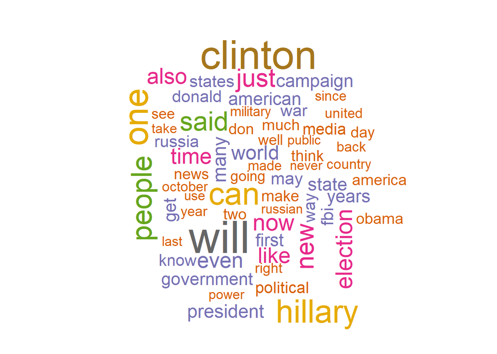

```r
fake_indices = which(sub_data$label == "FAKE")
real_indices = which(sub_data$label ==  "REAL")

library(wordcloud)
wordcloud(clean_corpus[fake_indices], min.freq=180, colors=brewer.pal(8, "Dark2"))
```

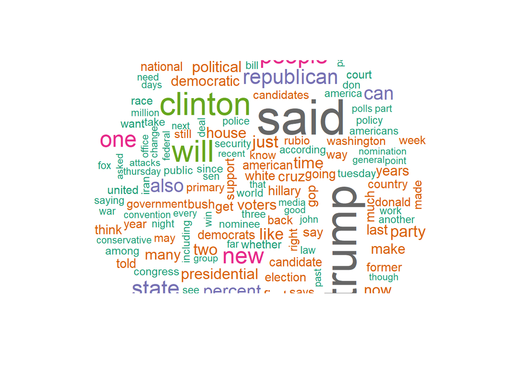

```r
wordcloud(clean_corpus[real_indices], min.freq=180, colors=brewer.pal(8, "Dark2"))
```

### Creating the training and the test

The dataset is divided into train and test (75% trainning and 25% for test) as well as the cleanned corpus.

```r
nobs=dim(sub_data)[1]
train = 1:round(nobs*0.75)
test = (round(nobs*0.75)+1):nobs
data_train = sub_data[train,]
data_test = sub_data[test,]

corpus_train <- clean_corpus[train]
corpus_test <- clean_corpus[test]
```

### Calculation of the frequency of the terms

Using DocumentTermMatrix, we create a sparse matrix data structure in which the rows of the matrix refer to document and the columns refer to words.

```r
data_DTM = DocumentTermMatrix(clean_corpus)
inspect(data_DTM[1:4, 3:10])
```

```
## <<DocumentTermMatrix (documents: 4, terms: 8)>>
## Non-/sparse entries: 11/21
## Sparsity           : 66%
## Maximal term length: 12
## Weighting          : term frequency (tf)
## Sample             :
##     Terms
## Docs accounts acknowledged act acting admitted aide also appearances
##    1        2            1   1      1        1    1    2           1
##    2        0            0   1      0        0    0    1           0
##    3        0            0   0      0        0    0    0           0
##    4        0            0   0      0        0    0    3           0
```

Now, the matrix is divided into test and training rows:

```r
data_DTM_train = data_DTM[train,]
data_DTM_test = data_DTM[test,]
```

### Identify frequently used words

The classifier does not to be worried with words that do not appear more than 5 times.

```r
five_times_words = findFreqTerms(data_DTM_train, 5)
length(five_times_words)
```

```
## [1] 7505
```

```r
five_times_words[1:5]
```

```
## [1] "according"    "account"      "accounts"     "acknowledged" "act"
```

```r
data_DTM_train = DocumentTermMatrix(corpus_train, control=list(dictionary = five_times_words))
data_DTM_test = DocumentTermMatrix(corpus_test, control=list(dictionary = five_times_words))
```

### Converting document-term matrices

Naive Bayes classification needs present or absent information on each word in a message, so the count information is transformed into *yes* or *no*.

```r
convert_count <- function(x){
  y <- ifelse(x > 0, 1,0)
  y <- factor(y, levels=c(0,1), labels=c("No", "Yes"))
  y
}
```

Now we convert the document-term matrices.

```r
data_DTM_train = apply(data_DTM_train, 2, convert_count)
data_DTM_train[1:4, 30:35]
```

```
##     Terms
## Docs comes communications conduct conducting confronted continued
##    1 "Yes" "Yes"          "Yes"   "Yes"      "Yes"      "Yes"
##    2 "No"  "No"           "No"    "No"       "No"       "No"
##    3 "No"  "No"           "No"    "No"       "No"       "No"
##    4 "No"  "No"           "No"    "No"       "No"       "No"
```

```r
data_DTM_test = apply(data_DTM_test, 2, convert_count)
data_DTM_test[1:4, 3:10]
```

```
##     Terms
## Docs action ads   aftermath along already also  although always
##    1 "Yes"  "Yes" "Yes"     "Yes" "Yes"   "Yes" "Yes"    "Yes"
##    2 "No"   "No"  "No"      "Yes" "No"    "No"  "No"     "No"
##    3 "No"   "No"  "No"      "No"  "No"    "No"  "No"     "No"
##    4 "Yes"  "No"  "No"      "No"  "No"    "Yes" "No"     "Yes"
```

### Naive Bayes Classifier

The Naive Bayes Classifier is created using the training dataset and the following package.

```r
library(e1071)

classifier = naiveBayes(data_DTM_train, data_train$label)
```

### Evaluation of the test

```r
data_DTM_test = as.data.frame(data_DTM_test)
```

```r
predictions = predict(classifier, newdata=data_DTM_test)

table(predictions, data_test$label)
```

```
##
## predictions FAKE REAL
##        FAKE   87   30
##        REAL   19   64
```

### Bayesian Naive Bayes Classifier

The Bayesian Naive Bayes with uniform priors is equivalent to the frequently called “Laplacian smoothing” (so the probability of a word will no longer be zero even if a word is not present in the training dataset).

```r
B.clas = naiveBayes(data_DTM_train, data_train$label,laplace = 1)


B.preds = predict(B.clas, newdata=data_DTM_test)
table(B.preds, data_test$label)
```

```
##
## B.preds FAKE REAL
##    FAKE   87   31
##    REAL   19   63
```

## Detect news by its title

In this part, the same procedure as before is done, but using the titles of the news.

### Prepare and Clean the Corpus

```r
library(tm)
corpus_titles = Corpus(VectorSource(sub_data$title))
inspect(corpus_titles[1:5])
```

```
## <<SimpleCorpus>>
## Metadata:  corpus specific: 1, document level (indexed): 0
## Content:  documents: 5
##
## [1] Defense Secretary Carter used personal email in first months on the job
## [2] Obama says Republican budget just helps the rich. Is he right?
## [3] Number of the week: How long until Russia can end its oil dependence?
## [4] Paul Manafort resigns from Trump campaign
## [5] Whoâ\200\231s ruling out a 2016 bid?
```

Same as before, the titles are not cleanned.

Firstly, the letters are transformed into lower case.

```r
clean_corpus_titles = tm_map(corpus_titles, tolower)
```

The following steps are to remobe numbers, punctuation, stopwords (as the news are in english, it is specified for english words) and if there are excess of white spaces:

```r
clean_corpus_titles = tm_map(clean_corpus_titles, removeNumbers)
clean_corpus_titles = tm_map(clean_corpus_titles, removePunctuation)
clean_corpus_titles = tm_map(clean_corpus_titles, removeWords,
                       stopwords("en"))
clean_corpus_titles = tm_map(clean_corpus_titles, stripWhitespace)
inspect(clean_corpus_titles[1:5])
```

```
## <<SimpleCorpus>>
## Metadata:  corpus specific: 1, document level (indexed): 0
## Content:  documents: 5
##
## [1] defense secretary carter used personal email first months job
## [2] obama says republican budget just helps rich right
## [3] number week long russia can end oil dependence
## [4] paul manafort resigns trump campaign
## [5] whoâ\200\231s ruling bid
```

As the previous part, the corpus/titles have “weird characters” that need to be removed.

```r
toSpace = content_transformer(function(x, pattern) gsub(pattern, " ", x))

clean_corpus_titles = tm_map(clean_corpus_titles, toSpace, "â")
clean_corpus_titles = tm_map(clean_corpus_titles, toSpace, "~")
clean_corpus_titles = tm_map(clean_corpus_titles, toSpace, "€")
clean_corpus_titles = tm_map(clean_corpus_titles, toSpace, "™")
clean_corpus_titles = tm_map(clean_corpus_titles, toSpace, "#")
clean_corpus_titles = tm_map(clean_corpus_titles, toSpace, "@")
clean_corpus_titles = tm_map(clean_corpus_titles, toSpace, "œ")
clean_corpus_titles = tm_map(clean_corpus_titles, toSpace, "\u009d") #to remove some \
clean_corpus_titles = tm_map(clean_corpus_titles, toSpace, "“")
clean_corpus_titles = tm_map(clean_corpus_titles, toSpace, "”")
inspect(clean_corpus_titles[1:5])
```

```
## <<SimpleCorpus>>
## Metadata:  corpus specific: 1, document level (indexed): 0
## Content:  documents: 5
##
## [1] defense secretary carter used personal email first months job
## [2] obama says republican budget just helps rich right
## [3] number week long russia can end oil dependence
## [4] paul manafort resigns trump campaign
## [5] who   s ruling bid
```

Now the corpus looks much better, the only thing that it is needed is to remove the excess of white spaces caused when a “weird character” is removed.

```r
clean_corpus_titles = tm_map(clean_corpus_titles, stripWhitespace)
inspect(clean_corpus_titles[1:5])
```

```
## <<SimpleCorpus>>
## Metadata:  corpus specific: 1, document level (indexed): 0
## Content:  documents: 5
##
## [1] defense secretary carter used personal email first months job
## [2] obama says republican budget just helps rich right
## [3] number week long russia can end oil dependence
## [4] paul manafort resigns trump campaign
## [5] who s ruling bid
```

### WordClouds

The indices of fake and real news are the same as the previous part as the same partition of the data is used. Combining the indices and the clean corpus we can have a visualization of the words. .

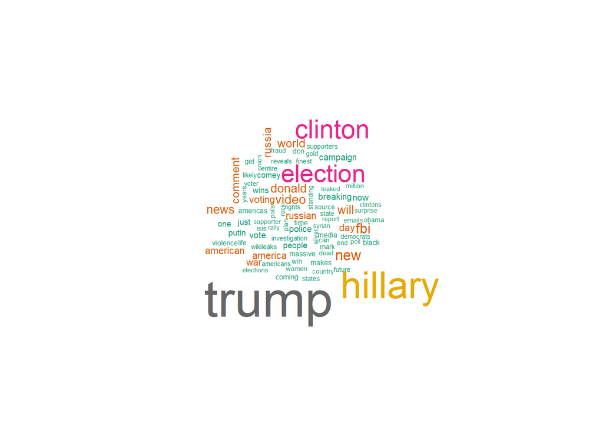

```r
wordcloud(clean_corpus_titles[fake_indices], min.freq=500,max.words = 85,scale=c(3.5,0.25),colors=brewer.pal(8, "Dark2"))
```

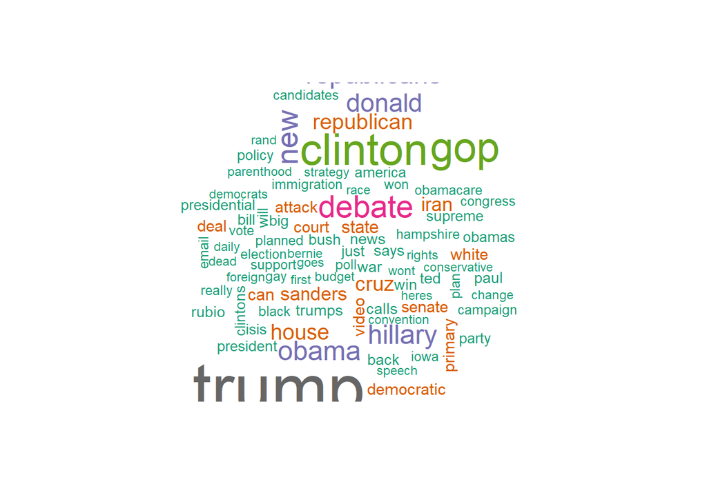

```r
wordcloud(clean_corpus_titles[real_indices], min.freq=500,max.words =85,colors=brewer.pal(8, "Dark2"))
```

*Note:* I had to put a maximum of words because, unlike the text, in the titles the words are much more repited and a lot of warnings appeared.

### Creating the training and the test

The dataset is divided into train and test (75% trainning and 25% for test) as well as the cleanned corpus (same partitions as the previous part).

```r
corpus_train_titles = clean_corpus_titles[train]
corpus_test_titles = clean_corpus_titles[test]
```

### Calculation of the frequency of the terms

Using DocumentTermMatrix, we create a sparse matrix data structure in which the rows of the matrix refer to document and the columns refer to words.

```r
titles_DTM = DocumentTermMatrix(clean_corpus_titles)
inspect(titles_DTM[1:4, 3:10])
```

```
## <<DocumentTermMatrix (documents: 4, terms: 8)>>
## Non-/sparse entries: 8/24
## Sparsity           : 75%
## Maximal term length: 9
## Weighting          : term frequency (tf)
## Sample             :
##     Terms
## Docs budget email first job months personal secretary used
##    1      0     1     1   1      1        1         1    1
##    2      1     0     0   0      0        0         0    0
##    3      0     0     0   0      0        0         0    0
##    4      0     0     0   0      0        0         0    0
```

Now, the matrix is divided into test and training rows:

```r
titles_DTM_train = titles_DTM[train,]
titles_DTM_test = titles_DTM[test,]
```

### Identify frequently used words

The classifier does not to be worried with words that do not appear more than 5 times.

```r
five_titles_words = findFreqTerms(titles_DTM_train, 5)
length(five_titles_words)
```

```
## [1] 134
```

```r
five_titles_words[1:5]
```

```
## [1] "email"    "first"    "personal" "budget"   "just"
```

```r
titles_DTM_train = DocumentTermMatrix(corpus_train_titles, control=list(dictionary = five_titles_words))
titles_DTM_test = DocumentTermMatrix(corpus_test_titles, control=list(dictionary = five_titles_words))
```

### Converting document-term matrices

Now we convert the document-term matrices.

```r
titles_DTM_train = apply(titles_DTM_train, 2, convert_count)
titles_DTM_train[1:4, 30:35]
```

```
##     Terms
## Docs clinton obamas debate gop  party battle
##    1 "No"    "No"   "No"   "No" "No"  "No"
##    2 "No"    "No"   "No"   "No" "No"  "No"
##    3 "No"    "No"   "No"   "No" "No"  "No"
##    4 "No"    "No"   "No"   "No" "No"  "No"
```

```r
titles_DTM_test = apply(titles_DTM_test, 2, convert_count)
titles_DTM_test[1:4, 3:10]
```

```
##     Terms
## Docs election can   paul  primary republican win   new  news
##    1 "No"     "No"  "No"  "No"    "No"       "No"  "No" "No"
##    2 "No"     "No"  "No"  "No"    "No"       "No"  "No" "No"
##    3 "Yes"    "No"  "No"  "No"    "No"       "No"  "No" "No"
##    4 "No"     "Yes" "Yes" "Yes"   "Yes"      "Yes" "No" "No"
```

### Naive Bayes Classifier

The Naive Bayes Classifier is created using the training dataset and the following package.

```r
classifier = naiveBayes(titles_DTM_train, data_train$label)
```

### Evaluation of the test

```r
titles_DTM_test = as.data.frame(titles_DTM_test)
```

```r
predictions = predict(classifier, newdata=titles_DTM_test)

table(predictions, data_test$label)
```

```
##
## predictions FAKE REAL
##        FAKE   91   46
##        REAL   15   48
```

### Bayesian Naive Bayes Classifier

```r
B.titles = naiveBayes(titles_DTM_train, data_train$label,laplace = 1)


B.preds_titles = predict(B.titles, newdata=titles_DTM_test)
table(B.preds_titles, data_test$label)
```

```
##
## B.preds_titles FAKE REAL
##           FAKE   92   48
##           REAL   14   46
```

## Conclusions about the results

After all the computations, we can conclude that it seems easier to detect fake news than real news. Also, that including a Bayesian Naive Bayes Classifier with laplace of 1 only helps (in small significant way) to the filtering of fake news. As well, though classifing news by title it has been proved to get more or less satisfactory results, using a corpus that it is from the new itself (the text) has given us much better results.